# Statistics with R, class 17

t* tests

Grzegorz Krajewski Faculty of Psychology University of Warsaw krajewski@psych.uw.edu.pl

12 December 2024

# Previously in “Statistics with *R*”…

## Standardised sampling distribution of mean

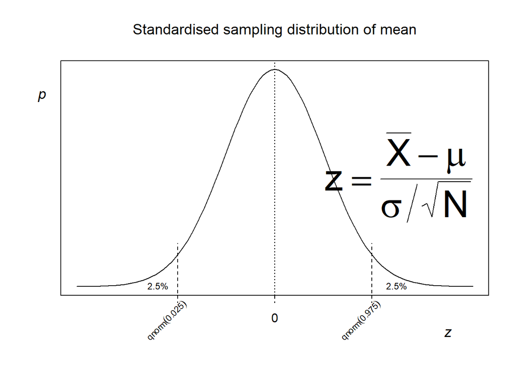

## Standardised sampling distribution of mean

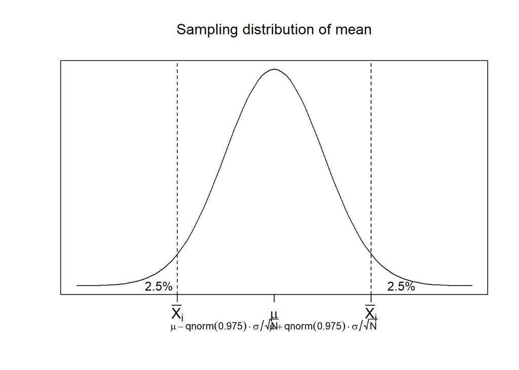

## *t* distribution

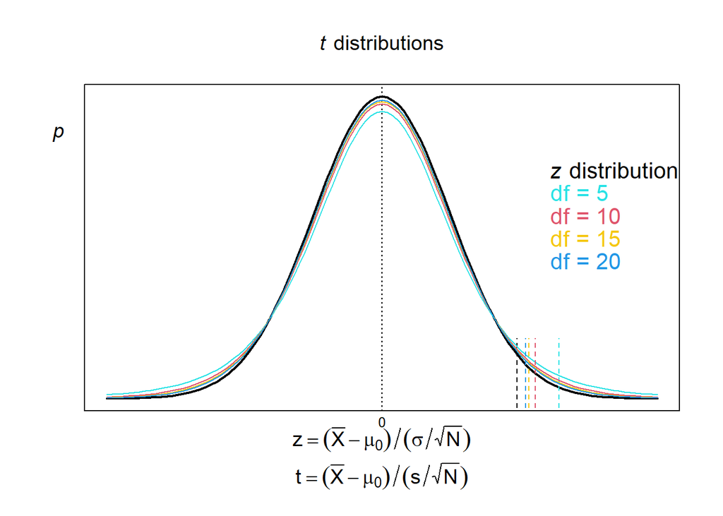

## *t* distribution

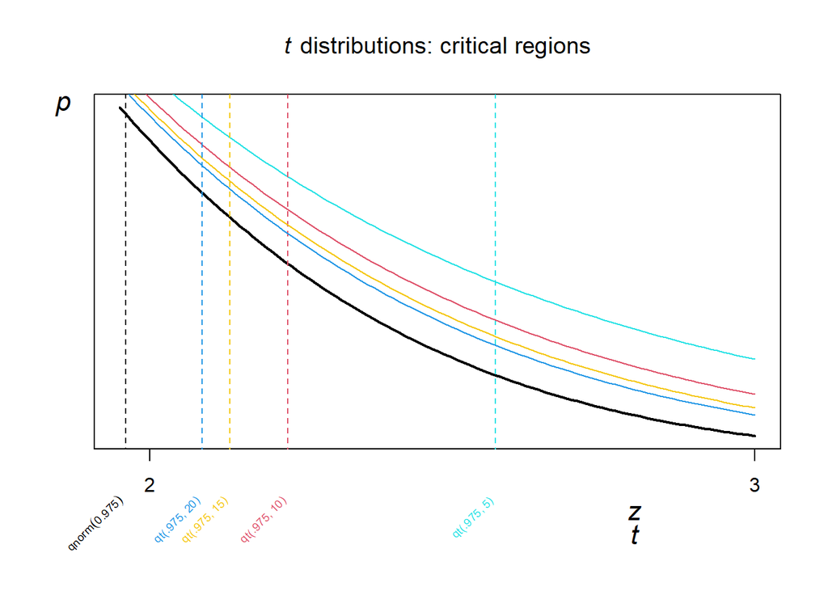

## Confidence interval around sample mean

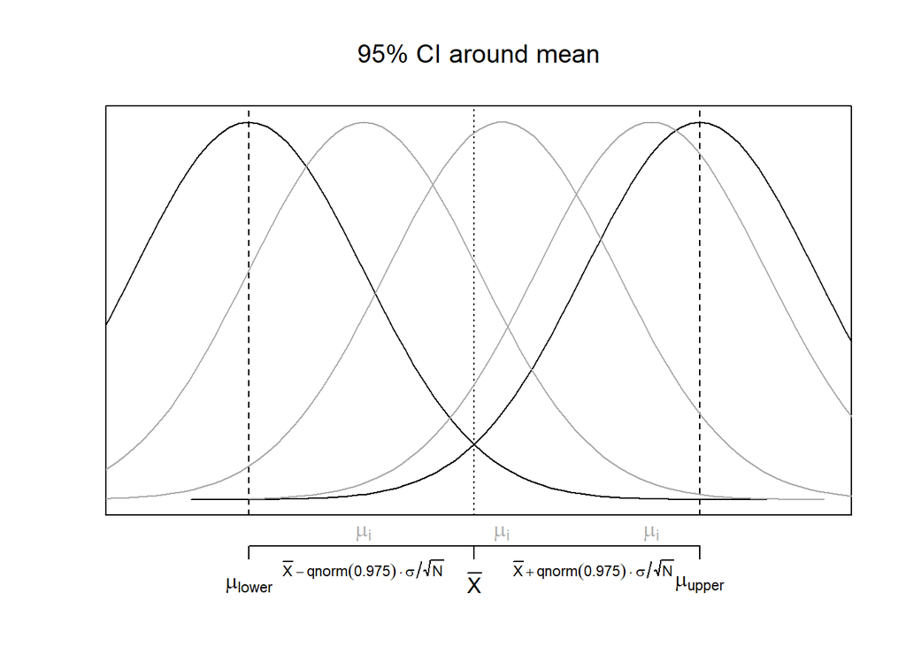

## Standardised sampling distribution of mean

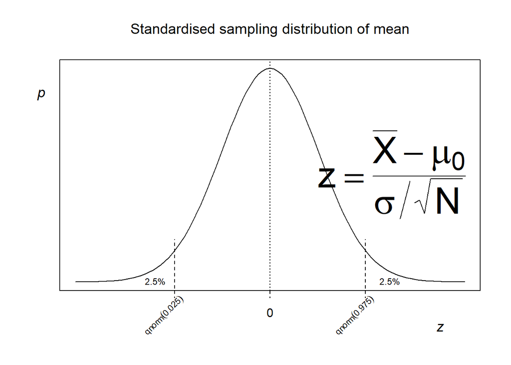

## Standardised sampling distribution of mean

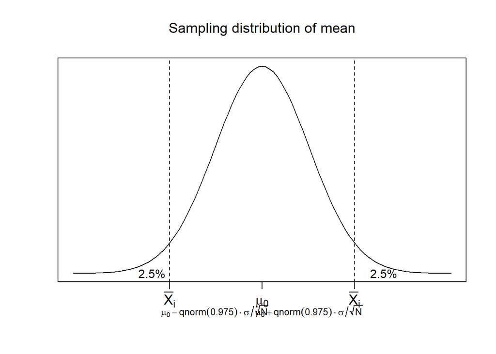

# One-sample tests of mean

## Lady tasting tea

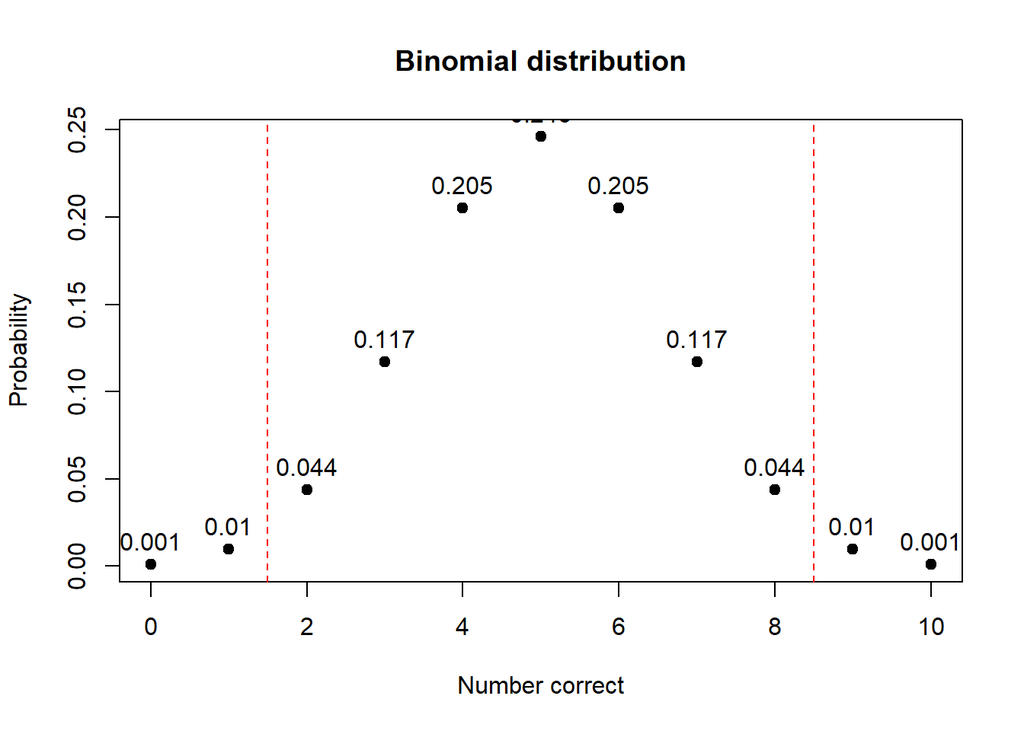

## Statistical tests

- Assume *null hypothesis*, $h_0$ (perhaps make other necessary *assumptions* too).
- Decide on *significance level* $\alpha$ (conventionally default to 0.05).
- Construct *sample distribution* of the *test statistic*, assuming the truth of $h_0$ (and considering the other assumptions).
- Identify *critical region* (based on $\alpha$).
- Draw a random sample, collect measurements, calculate the statistic.
- Reject, or not, $h_0$.

## *z* test

- 30 CogSci students’ mean IQ is 105.
- Do they come from the population with mean IQ = 100?
- $h_0$: $\mu_0 = 100$
- $z = (\bar{X} - \mu_0) / (\sigma / \sqrt{N})$

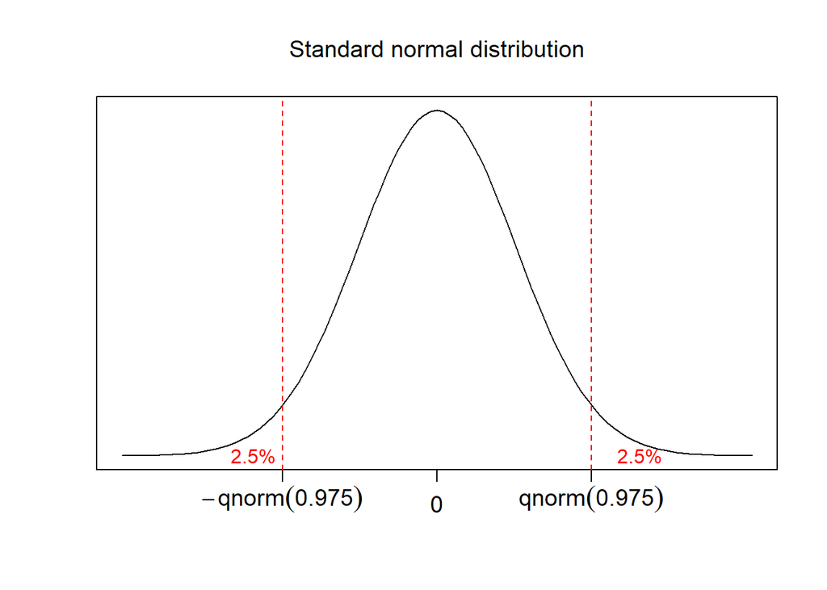

## One sample *t* test (1)

- From many years’ experience we know that CogSci students pass a particular exam with an average score of 26.5. This year there are 10 new students and their scores are:

```r
> scores <- c(10, 50, 46, 32, 37, 28, 41, 20, 32, 43)
```

- Are these students better than an average CogSci student?
  - I.e., do they come from a population with a different mean?
- $h_0$: $\mu_0 = 26.5$
- $t = (\bar{X} - \mu_0) / (s / \sqrt{N})$

## One sample *t* test (2)

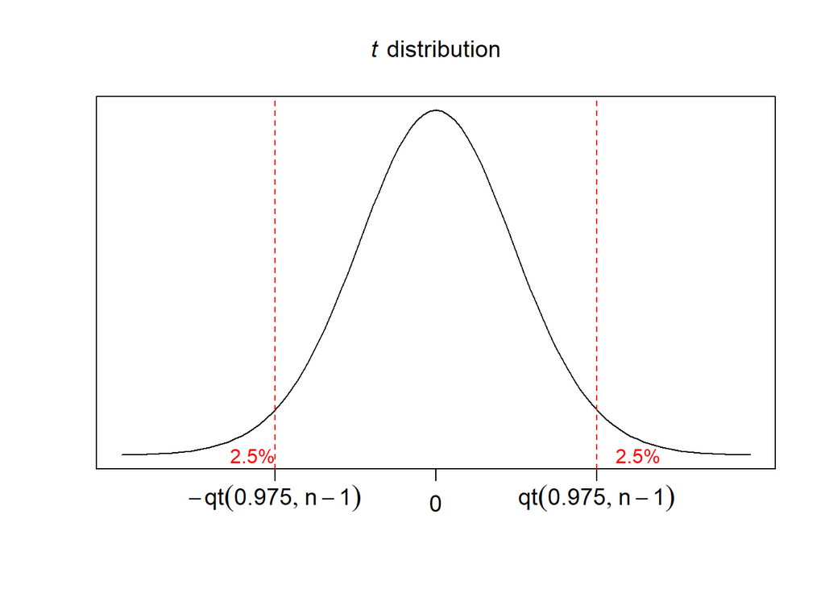

```r
> qt(.975, length(scores) - 1)
> t.statistic <- (mean(scores) - 26.5) /
+      (sd(scores) / sqrt(length(scores)))
```

## One sample *t* test (3)

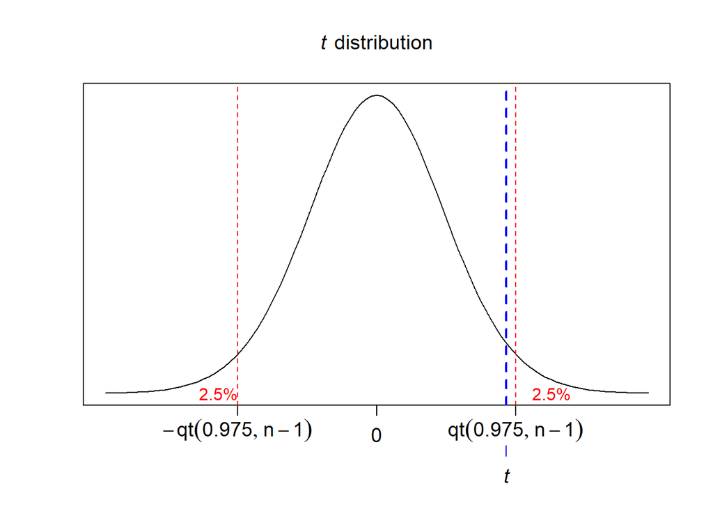

```r
> pt(t.statistic, length(scores) - 1, lower.tail=F) * 2
> # Times 2 to take into account the other tail!
```

# Paired-sample *t* test

## Paired-sample *t* test (1)

- Two paired samples
  - e.g., repeated measures, siblings etc.
  - differences between paired measurements
  - $h_0$: mean difference ($M$) = 0
- 49 CogSci students took IQ test before and after first semester and for each of them the difference between both scores was calculated
- The mean difference was 0.5 (in favour of the second measurement)
- Standard deviation of the differences was 1.75. Can we say that a semester of studying CogSci improves intelligence?
- $t = M / (s / \sqrt{N})$

```r
> .5 / (1.75 / sqrt(49))
> pt(2, 48, lower.tail=F) * 2
```

## Paired-sample *t* test (2)

- American scientists compared sexual satisfaction of women and men staying in long term relationships
- 15 couples were chosen at random and each person estimated their satisfaction on 1-5 scale
- There are 15 answers from men and 15 answers from women. Why should we compare them pairwise?

```r
> m <- c(1, 1, 2, 2, 3, 3, 3, 4, 4, 4, 4, 5, 5, 5, 5)
> f <- c(1, 1, 1, 2, 2, 2, 3, 3, 3, 3, 4, 4, 4, 5, 5)
> m - f # differences we want to analyse
```

```r
> mean(m-f) / (sd(m-f) / sqrt(length(m-f)))
```

# Two Sample *t* test

## Two independent samples

- Most of the time we deal with two samples that are not matched
- $h_0$: both samples come from populations with the same mean ($\mu_1 - \mu_2 = 0$)
- Statistic: difference between sample means ($\bar{X_1} - \bar{X_2}$)
- How does sampling distribution of $\bar{X_1} - \bar{X_2}$ look like?
- *Additional assumption*: both samples come from populations with the same variance ($\sigma^2_1 - \sigma^2_2 = 0$)

## Sampling distribution of $\bar{X_1} - \bar{X_2}$ (1)

- We know sampling distribution of a single mean
  - and can simulate it…

```r
> N <- 25; mu <- 100; sigma <- 15
> i <- 10000
> sampling_mean <- replicate(i,mean(rnorm(N,mu,sigma)))
```

- Check its shape, mean, and standard deviation (and variance)

```r
> hist(sampling_mean, prob = T) # simulation
> curve(dnorm(x, mu, sigma / sqrt(N)), add=T) # theory
```

```r
> mean(sampling_mean) # equals mu (population mean)
```

```r
> sd(sampling_mean) # simulation
> sigma / sqrt(N) # theory
```

## Sampling distribution of $\bar{X_1} - \bar{X_2}$ (2)

- Simulate sampling distribution of $\bar{X_1} - \bar{X_2}$

```r
> sampling_diff <- replicate(i,
+                            mean(rnorm(N, mu, sigma)) -
+                            mean(rnorm(N, mu, sigma)))
> hist(sampling_diff)
```

```r
> mean(sampling_diff) # equals 0 (consistent with h0)
> var(sampling_diff)
> (sigma^2 / N) * 2
```

## Sampling distribution of $\bar{X_1} - \bar{X_2}$ (3)

- Change parameters of one of the populations and see what happens

```r
> mu1 <- 100; sigma1 <- 15
> mu2 <- 110; sigma2 <- 10
> sampling_diff <- replicate(i,
+                            mean(rnorm(N, mu1, sigma1)) -
+                            mean(rnorm(N, mu2, sigma2)))
```

```r
> hist(sampling_diff)
```

```r
> mean(sampling_diff) # mu1 - mu2
> var(sampling_diff)
> sigma1^2 / N + sigma2^2 / N # sum of both variances
```

## Sampling distribution of $\bar{X_1} - \bar{X_2}$ (4)

- Sampling distribution of $\bar{X_1} - \bar{X_2}$:
  - Normal
  - $\mu = \mu_1 - \mu_2$
  - $\sigma_{\bar{X_1} - \bar{X_2}} = \sqrt{\sigma^2_{\bar{X_1}} + \sigma^2_{\bar{X_2}}}$

## Sampling distribution of $\bar{X_1} - \bar{X_2}$ (5)

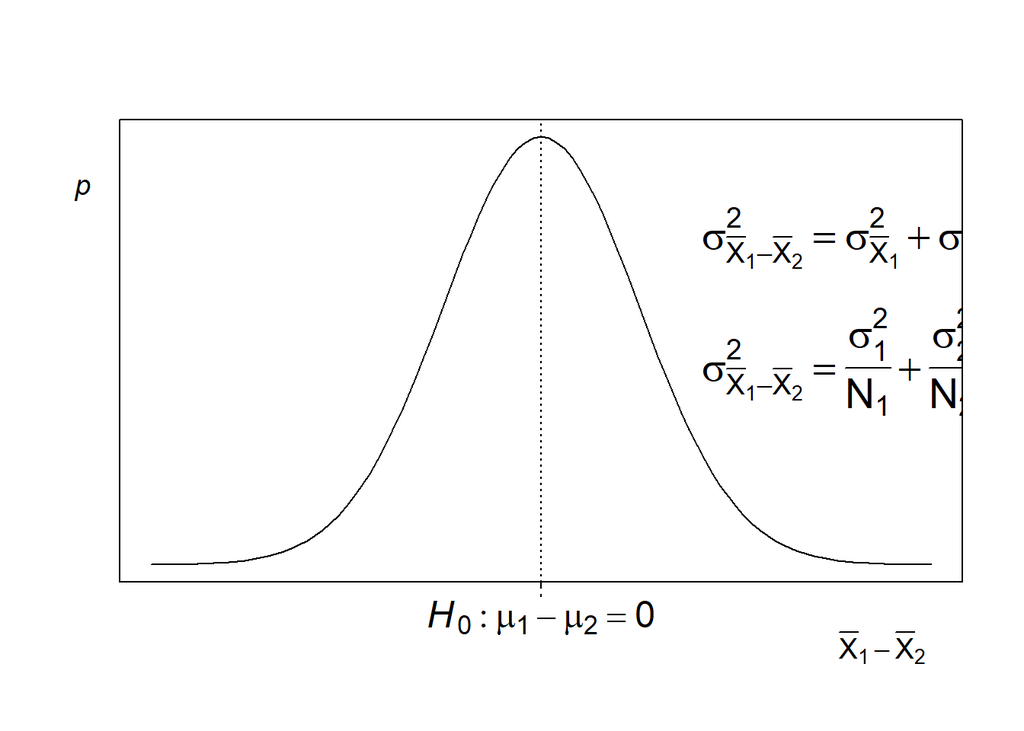

## Standardised sampling distribution of $\bar{X_1} - \bar{X_2}$

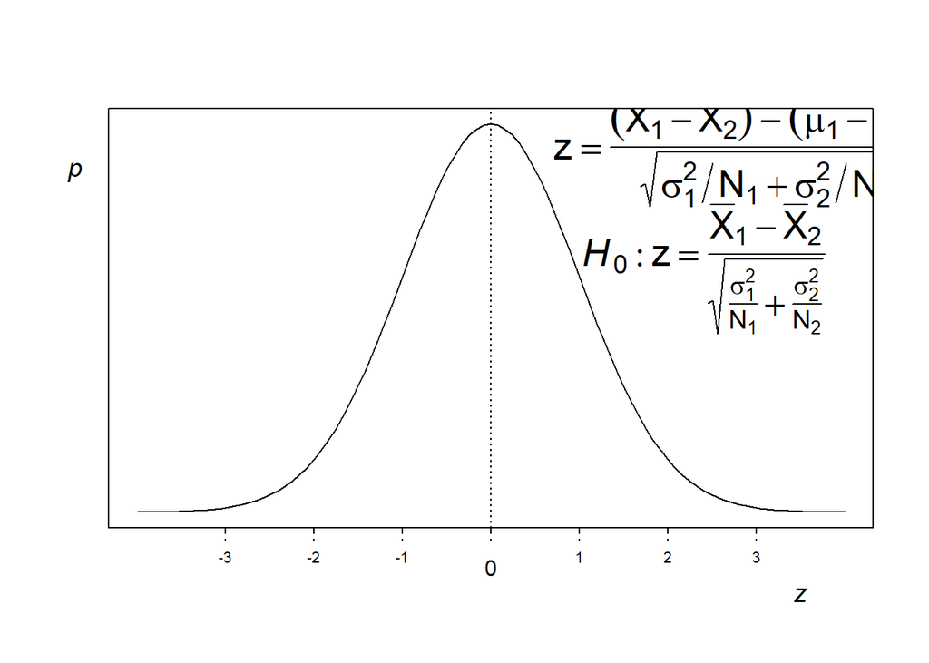

## Student’s *t* test

- $\sigma_1$ and $\sigma_2$ are unknown
- Assumption: $\sigma_1 = \sigma_2$
- $s_p$: weighted mean of $s_1$ and $s_2$
- $t = \frac{\bar{X_1} - \bar{X_2}}{s_p * \sqrt{1/N_1 + 1/N_2}}$
- $df = N_1 + N_2 - 2$
- If assumption $\sigma_1 = \sigma_2$ does not hold, Welch’s correction reduces $df$

```r
> t.test(m, f, paired = TRUE)
> t.test(m, f)
> t.test(m, f, var.equal = TRUE)
```

## Dependent *vs* independent *t* test

- dependent (paired samples) *vs* independent *t* test:
  - $t = \bar{D}/\frac{s_D}{\sqrt{N_D}}$,  
    where *D* = difference within pair
  - $t = (\bar{X_1} - \bar{X_2})/(\sqrt{s_p/N_1 + s_p/N_2})$,  
    where $s_p$ pooled from $s_1$ and $s_2$
  - denominator: *standard error*
- (not only) *t* test: an *effect* to *noise* ratio
  - pairing measurements reduces random variation (noise)